# T.S HW2

Sharon Liu

2022-10-25

# 資料描述

此次選擇標準普爾SP500、台股加權指數TWII、倫敦金融時報100指數(FTSE)、美金台幣貨幣對、英鎊台幣貨幣對與美金英鎊貨幣對，於2012-10-12到2022-10-12這段時間內的股價日資料，分別繪製其報酬率與對數報酬率的time plot、ACF與PACF，並進行Ljung Box Test，看資料是否有序列相關，若有序列相關將更進一步建立AR模型與建模後續檢定。

# 1.1 Daily Return of SP500

## Time Plot

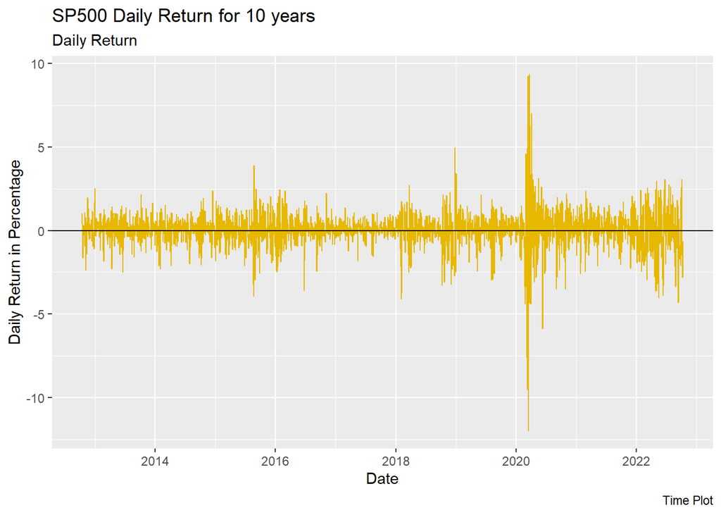

從上圖可以看到SP500的日報酬在2020年初之前的波動度大約在-5~5之間，直到2020年1月才有劇烈的變化，恰逢2020年1月至4月期間為2020國際金融恐慌，其起因於2019冠狀病毒病疫情在全球蔓延，並加以其他因素共同影響，導致全球金融市場的大幅動盪。

## ACF、PACF & Ljung Box Test

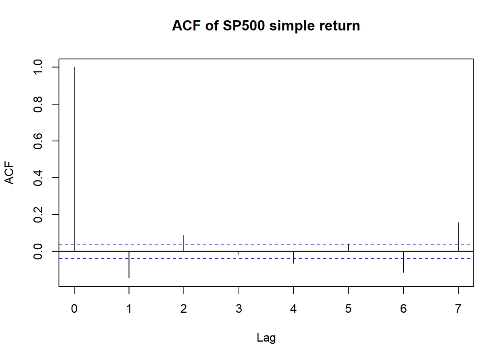

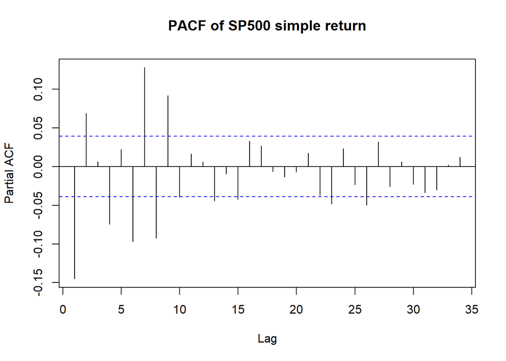

```
##
##  Box-Ljung test
##
## data:  data
## X-squared = 282.12, df = 10, p-value < 2.2e-16
```

# 1.2 Daily Return of TWII

## Time Plot

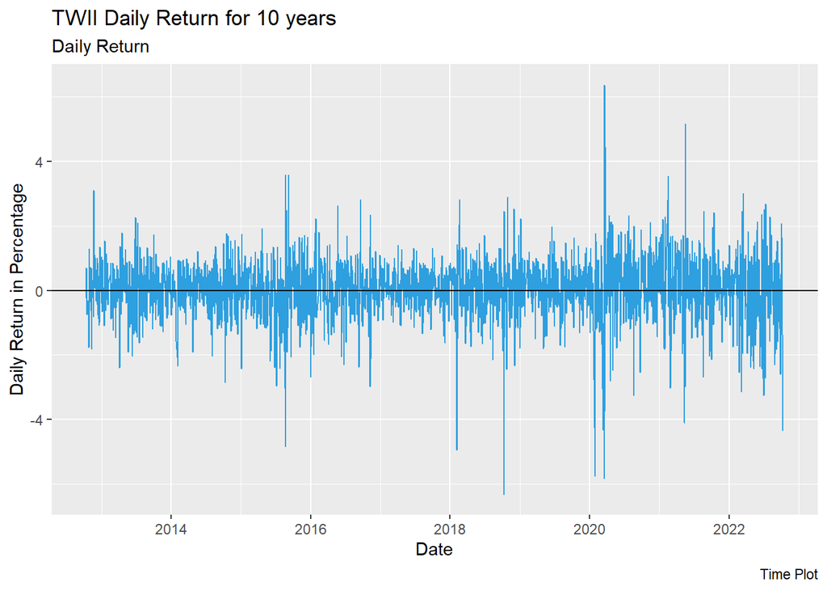

從上圖可以看到台股在2015年8月中國股災、2018年10月中美貿易戰、2020國際金融恐慌與2021年5月台灣三級警戒的時後，TWII的日報酬的波動相較於SP500明顯，也較不平穩，但其變動範圍仍較SP500小一些。

## ACF、PACF & Ljung Box Test

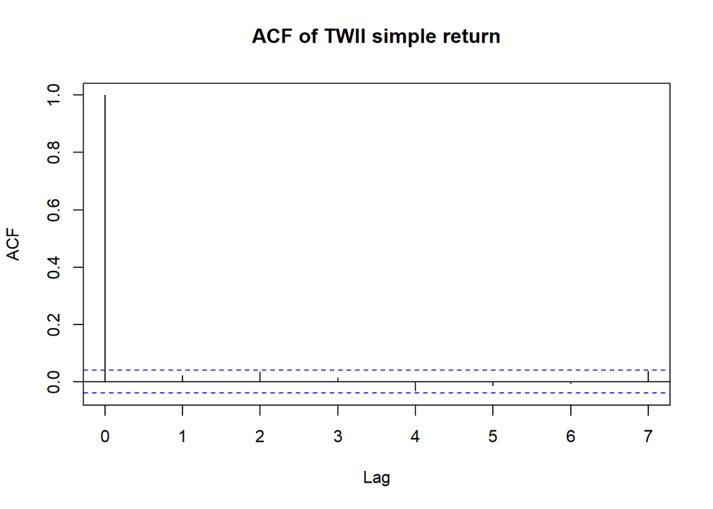

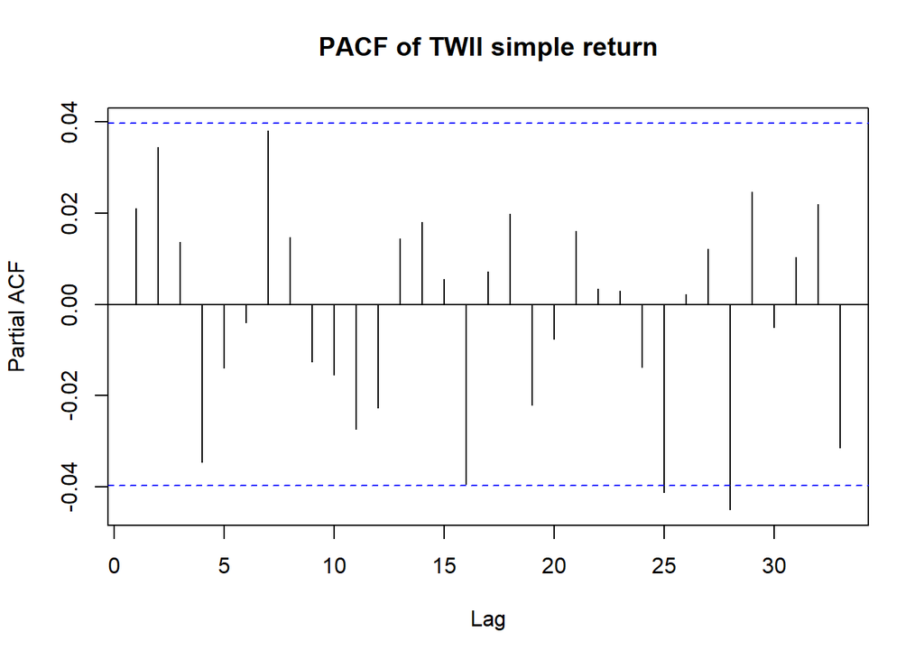

```
##
##  Box-Ljung test
##
## data:  data
## X-squared = 12.223, df = 10, p-value = 0.2704
```

從上圖TWII日報酬的ACF中沒有看到指數遞減的現象，第一期便cut off，且沒有任何一個lag是顯著的，由此來看資料並不存在自我相關性，此外，Ljung Box test其p-value=0.2704 > 0.05，意味著資料之間不存在序列相關性，故台股指數不會做後續AR的建模。

# 1.3 Daily Return of FTSE

## Time Plot

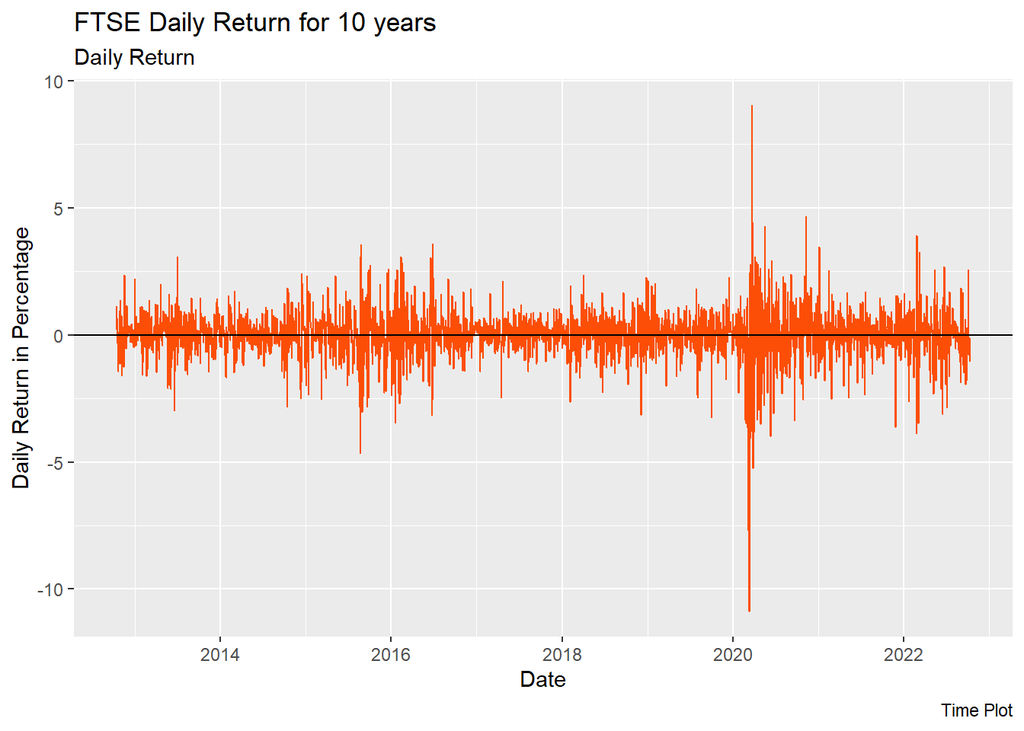

從上圖可以看到FTSE的日報酬在2020年初之前的波動度大約在-3~3之間，直到2020年1月才有劇烈的變化，恰逢2020年1月至4月期間為2020國際金融恐慌，FTSE的變化整體來說與SP500相仿。

## ACF、PACF & Ljung Box Test

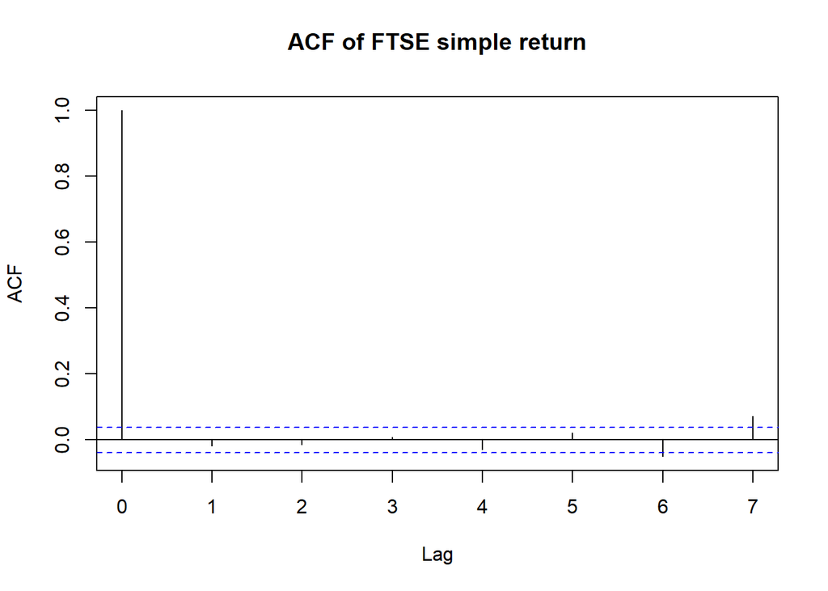

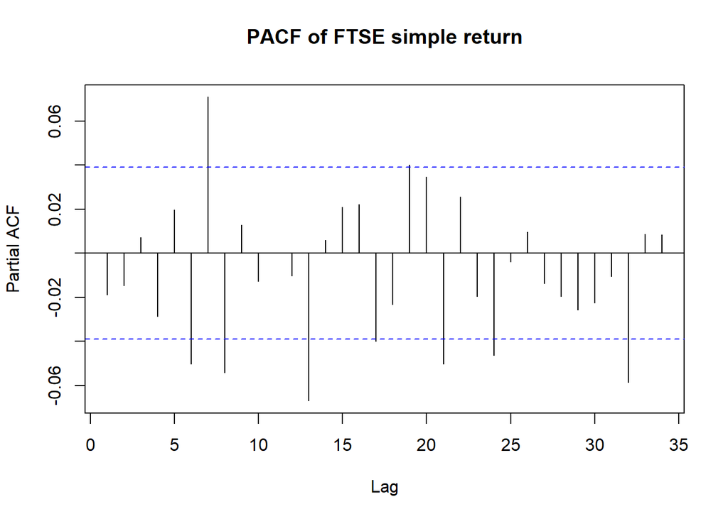

```
##
##  Box-Ljung test
##
## data:  data
## X-squared = 31.39, df = 10, p-value = 0.0005056
```

從上圖FTSE日報酬的ACF可以看到autocorrelation幾乎都是不顯著的，也沒有看到指數遞減的現象，故初步認為FTSE的日報酬並不存在自我相關性，但若更進一步做Ljung Box test其p-value < 0.05，意味著資料之間仍存在序列相關性，有鑑於此，我們仍會以此結果作為依據建立AR Model並進行後續模型診斷。

# 1.4 Daily Return of USD/TWD

## Time Plot

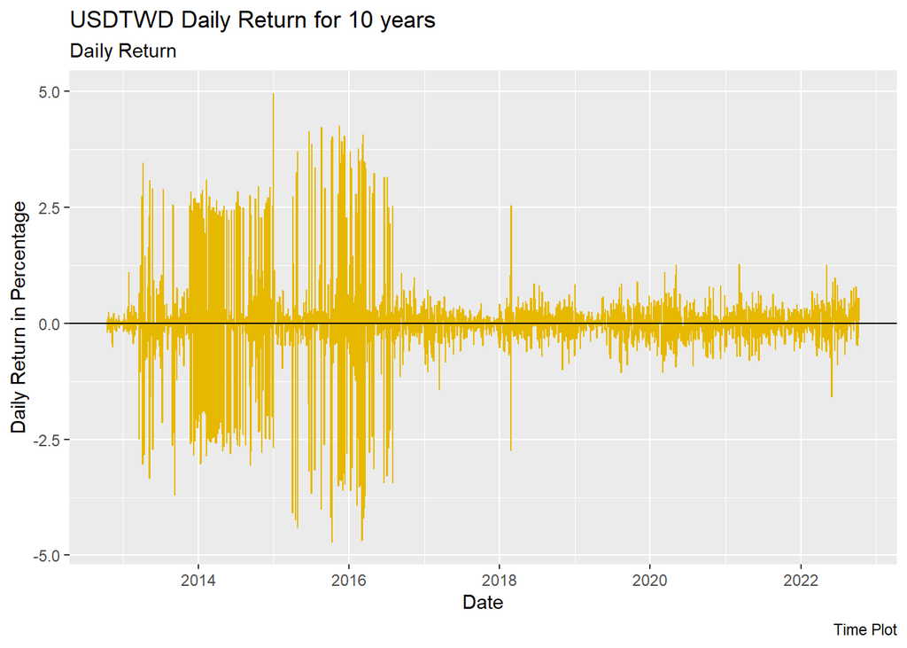

從上圖可以看到2013年初到2016年中USD/TWD的日報酬震盪較為劇烈，期間內查到的有2015新興市場金融風暴，而在2018年波動後趨緩，波動度大約在-2~2之間。

## ACF、PACF & Ljung Box Test

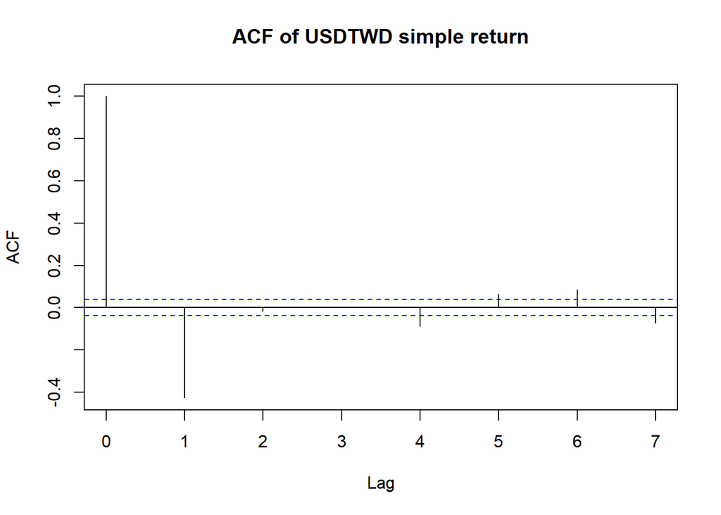

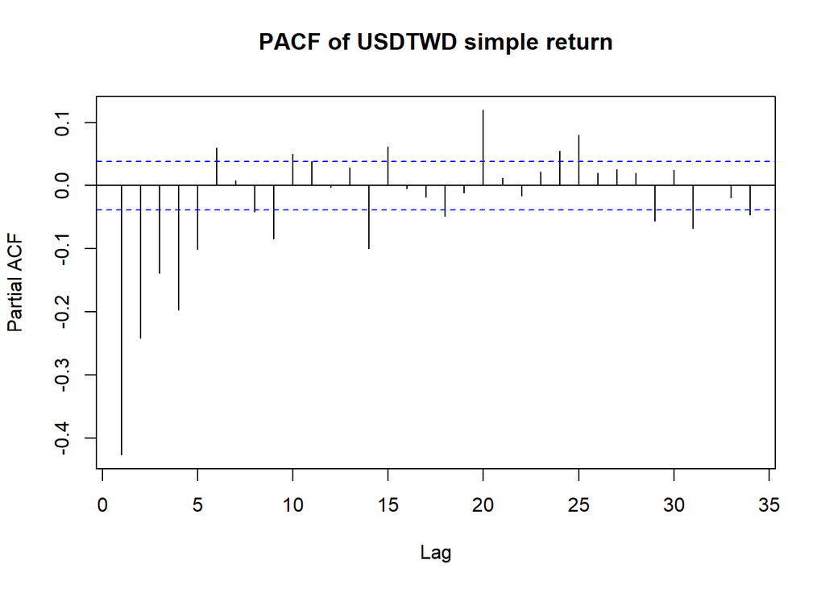

```
##
##  Box-Ljung test
##
## data:  data
## X-squared = 562.35, df = 10, p-value < 2.2e-16
```

# 1.5 Daily Return of GBP/TWD

## Time Plot

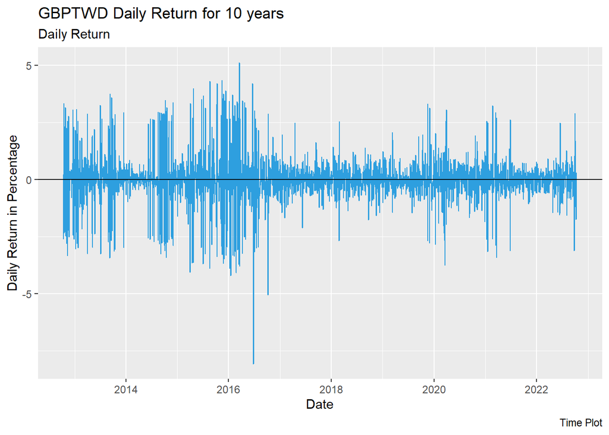

## ACF、PACF & Ljung Box Test

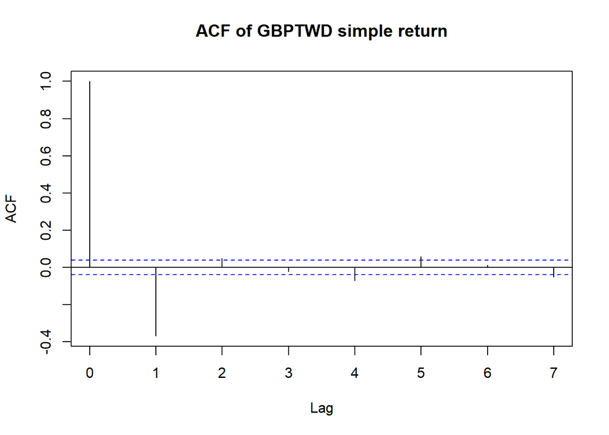

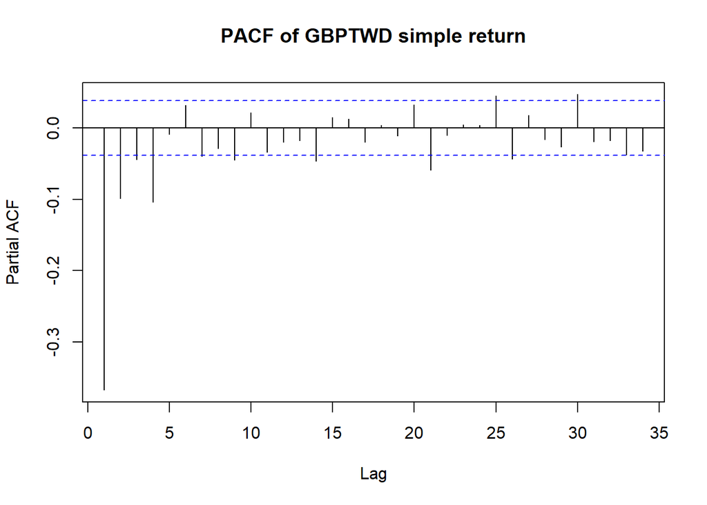

```
##
##  Box-Ljung test
##
## data:  data
## X-squared = 398.74, df = 10, p-value < 2.2e-16
```

# 1.6 Daily Return of USD/GBP

## Time Plot

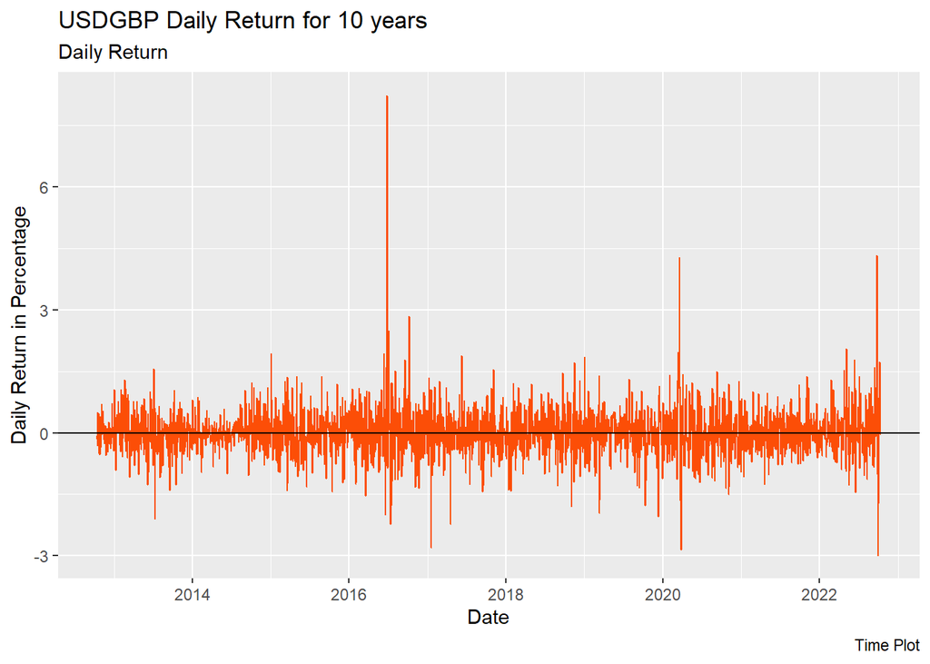

## ACF、PACF & Ljung Box Test

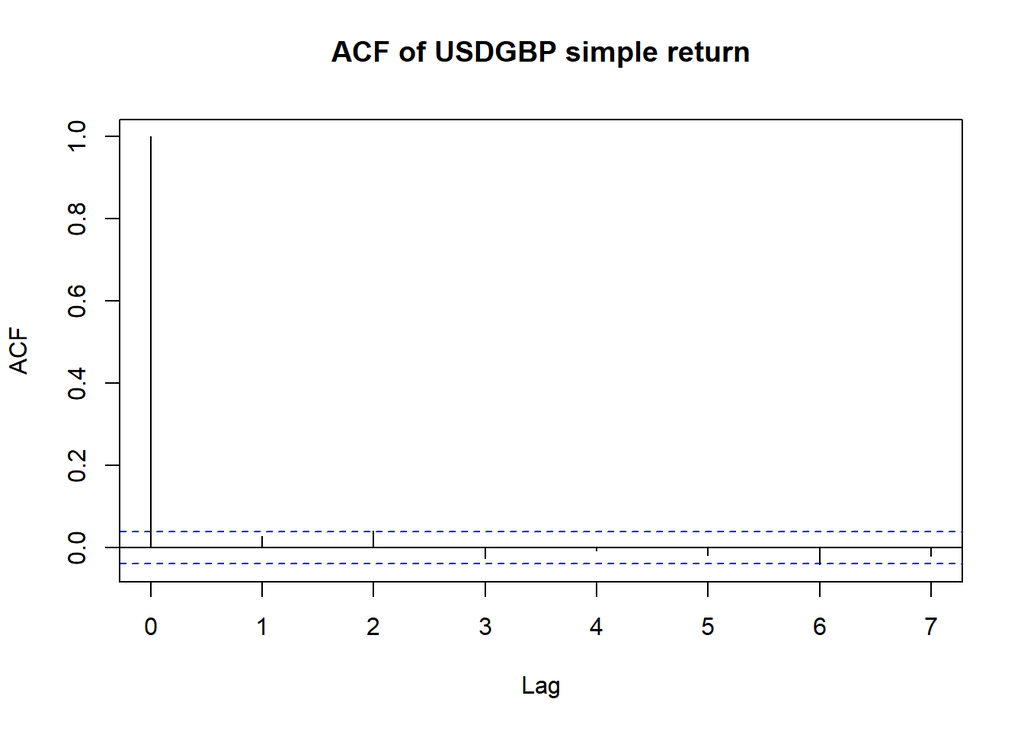

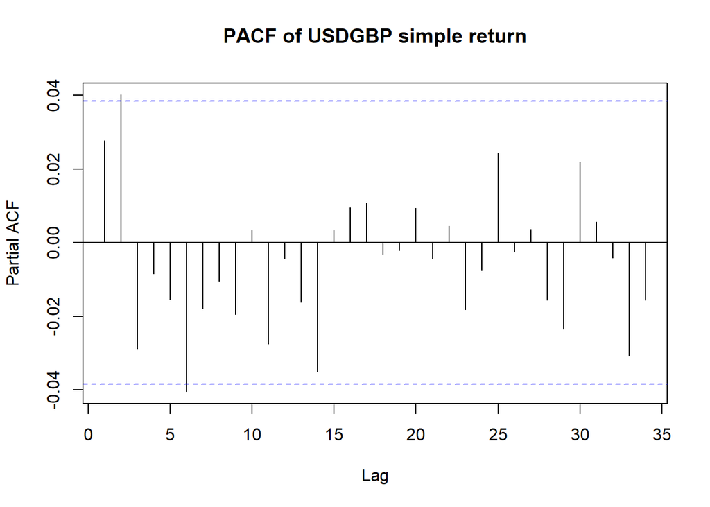

```
##
##  Box-Ljung test
##
## data:  data
## X-squared = 16.265, df = 10, p-value = 0.0923
```

從上圖美金英鎊貨幣對的日報酬的ACF中沒有看到指數遞減的現象，pacf圖中的lag也多為不顯著 ，由此判斷資料並不存在自我相關性，此外，Ljung Box test其p-value=0.0923 > 0.05，意味著資料之間不存在序列相關性，故美金英鎊貨幣對不會做後續AR的建模。

# 2.1 Daily Log Return of SP500

## Time Plot

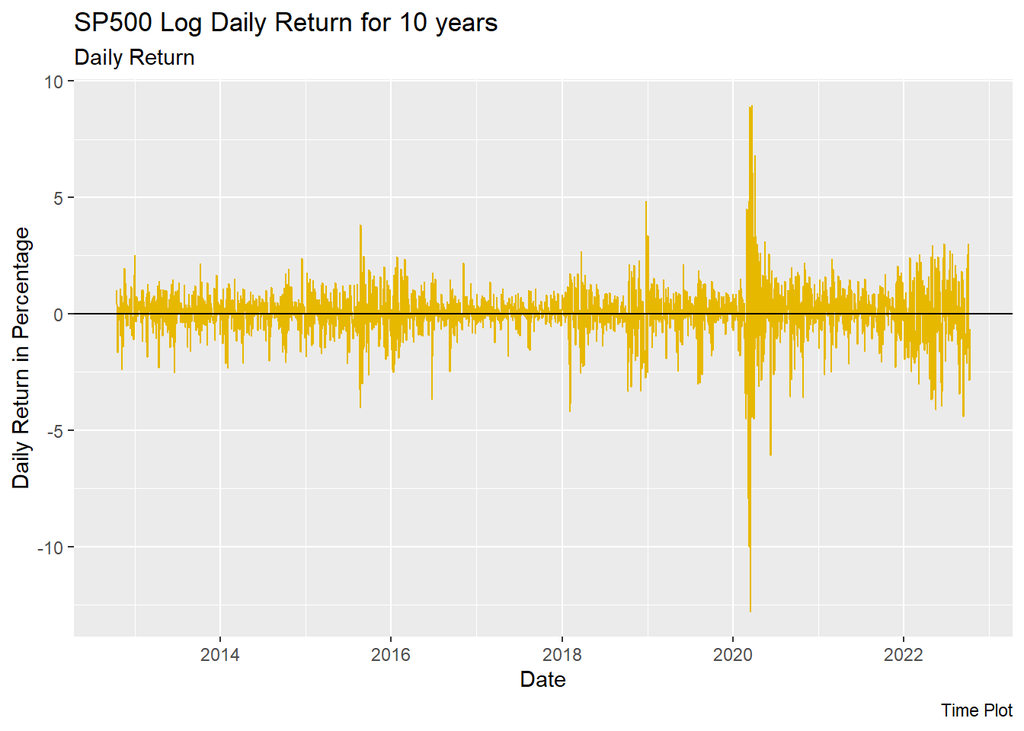

上圖為SP500對數日報酬，其與SP500的日報酬同樣在2020年1-4月有較大的波動，但在其他時間波動度大約在-5~5之間，與SP500日報酬的變化相仿。

## ACF、PAC & Ljung Box Test

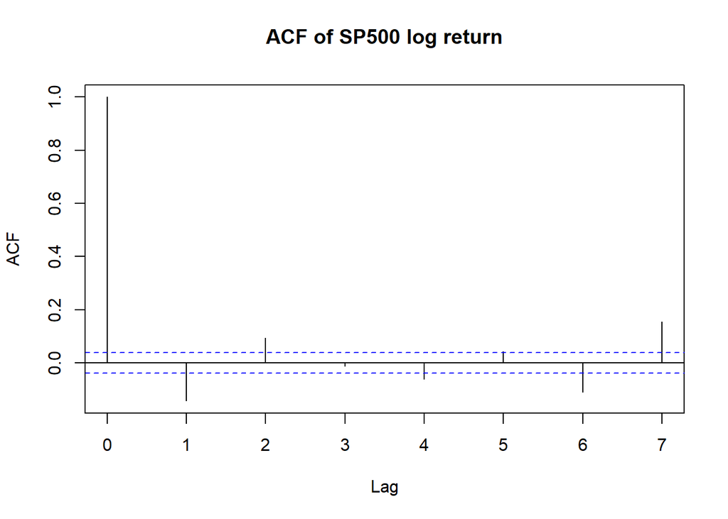

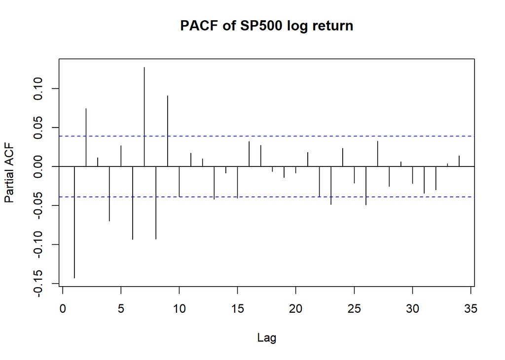

```
##
##  Box-Ljung test
##
## data:  data
## X-squared = 278.84, df = 10, p-value < 2.2e-16
```

上圖為SP500對數日報酬的ACF可以看到資料雖然有幾個lag是顯著的，但仍沒有看到指數遞減的現象，故初步認為SP500的日報酬並不存在自我相關性，但若更進一步做Ljung Box test其p-value < 0.05，意味著資料之間仍存在序列相關性，有鑑於此，我們仍會以此結果作為依據建立AR Model並進行後續模型診斷。

# 2.2 Daily Log Return of TWII

## Time Plot

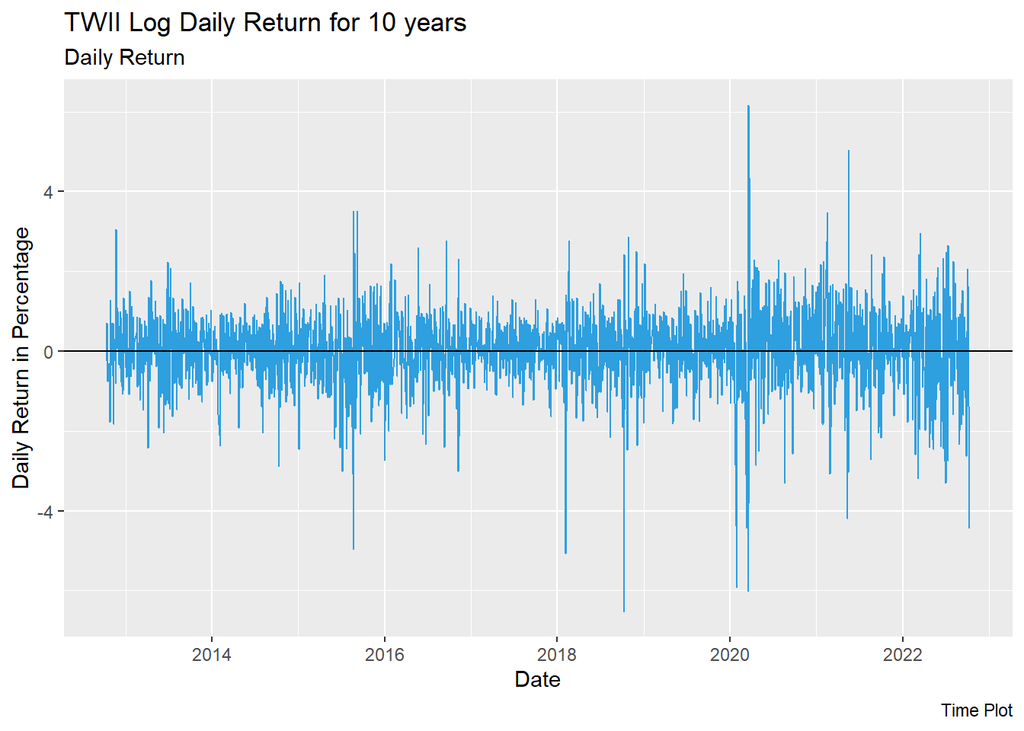

從上圖可以看到台股在2015年8月中國股災、2018年10月中美貿易戰、2020國際金融恐慌與2021年5月台灣三級警戒的時後，TWII的對數日報酬波動相較於SP500明顯，也較不平穩，與TWII 的日報酬有同樣的變化。

## ACF、PAC & Ljung Box Test

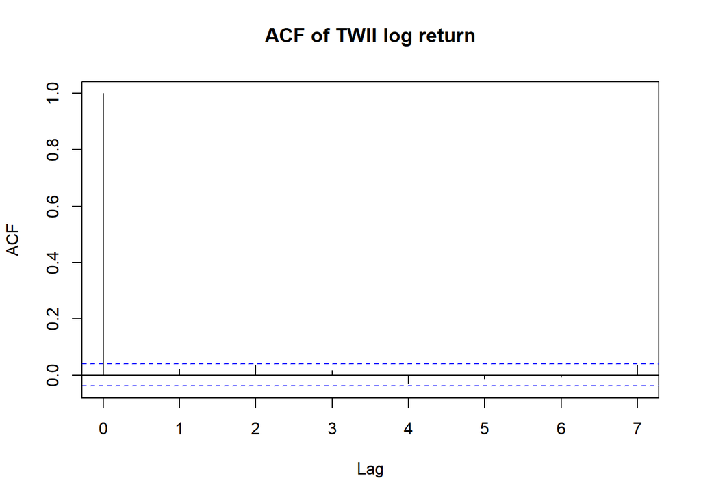

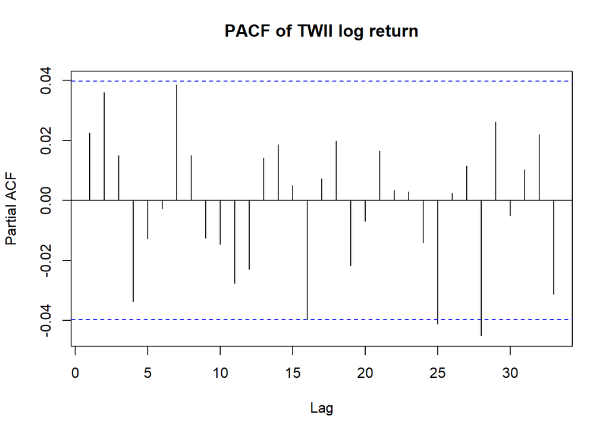

```
##
##  Box-Ljung test
##
## data:  data
## X-squared = 12.493, df = 10, p-value = 0.2534
```

從上圖TWII對數日報酬的ACF中沒有看到指數遞減的現象，第一期便cut off，且沒有任何一個lag是顯著的，由此來看資料並不存在自我相關性，此外，Ljung Box test其p-value=0.2534 > 0.05，意味著資料之間不存在序列相關性，故台股指數不會做後續AR的建模。

# 2.3 Daily Log Return of FTSE

## Time Plot

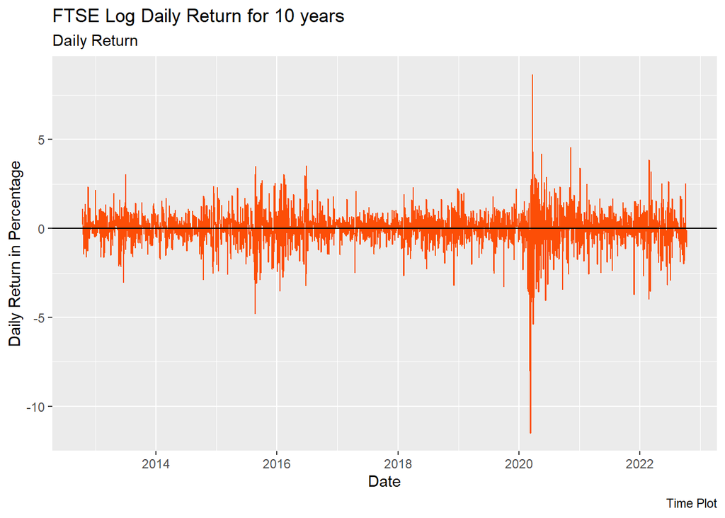

從上圖可以看到FTSE的對數日報酬在2020年初之前的波動度大約在-3~3之間，直到2020年1月才有劇烈的變化，恰逢2020年1月至4月期間為2020國際金融恐慌，FTSE的變化整體來說與SP500相仿，其對數日報酬的變化也與日報酬的變化相仿。

## ACF、PACF & Ljung Box Test

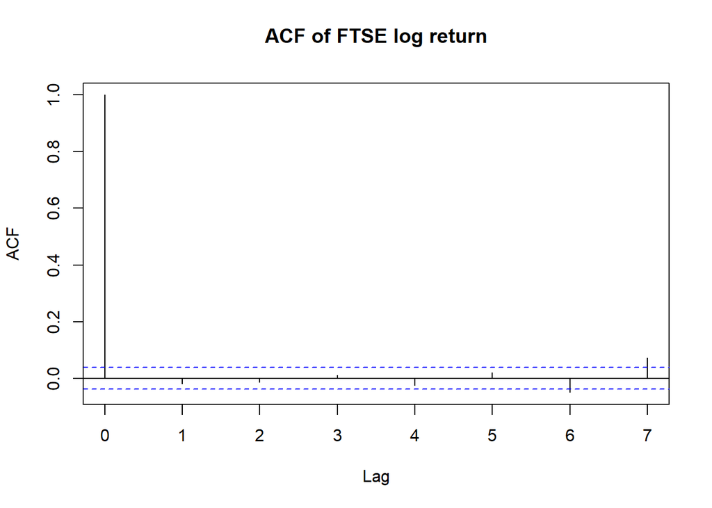

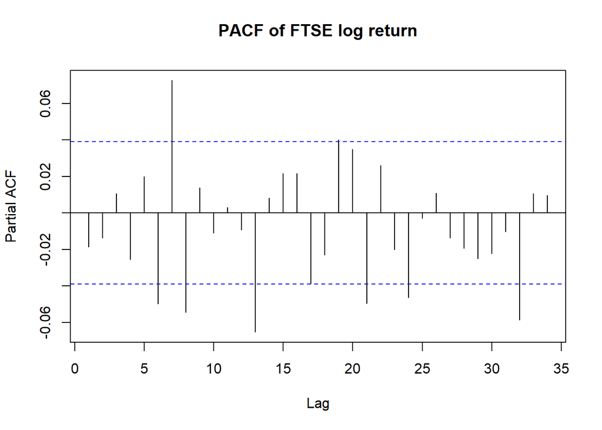

```
##
##  Box-Ljung test
##
## data:  data
## X-squared = 31.694, df = 10, p-value = 0.0004502
```

從上圖FTSE對數日報酬的ACF可以看到autocorrelation幾乎都是不顯著的，也沒有看到指數遞減的現象，故初步認為FTSE的日報酬並不存在自我相關性，但若更進一步做Ljung Box test其p-value < 0.05，意味著資料之間仍存在序列相關性，有鑑於此，我們仍會以此結果作為依據建立AR Model並進行後續模型診斷。

# 2.4 Daily Log Return of USDTWD

## Time Plot

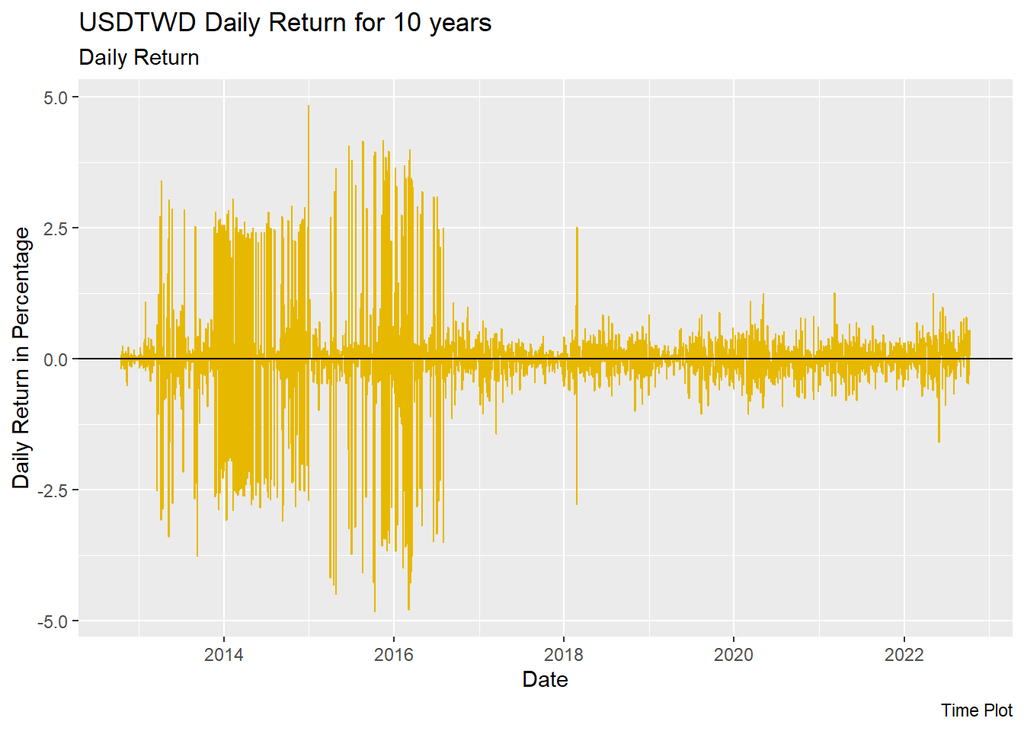

```r
logrttp.USDTWD=tidy(as.xts(logrt.USDTWD)) %>%
  ggplot(aes(x=index,y=value)) + geom_line(color="#E7B800") +geom_hline(yintercept = 0,color='black')+
  labs(title = paste(colnames(logrt.USDTWD),"Daily Return for 10 years"),subtitle = "Daily Return",caption = " Time Plot") +
  xlab("Date") + ylab("Daily Return in Percentage")
logrttp.USDTWD
```

從上圖可以看到2013年初到2016年中USD/TWD的日報酬震盪較為劇烈，期間內查到的有2015新興市場金融風暴，而在2018年波動後趨緩，波動度大約在-2~2之間，其對數日報酬的變化也與日報酬的變化相仿。

## ACF、PAC & Ljung Box Test

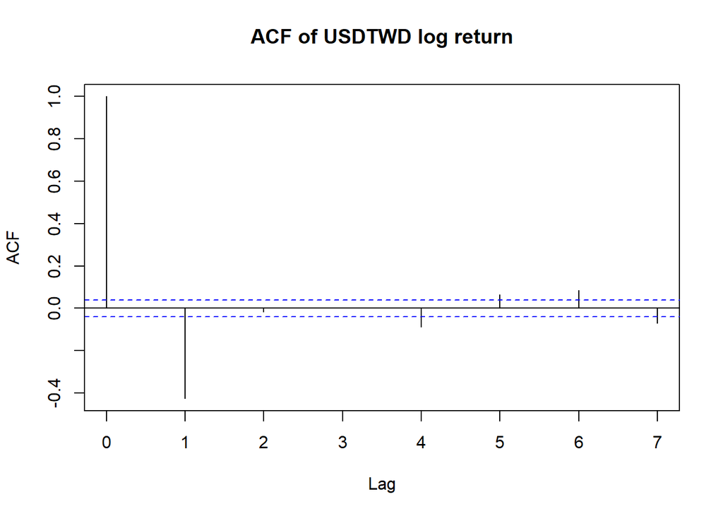

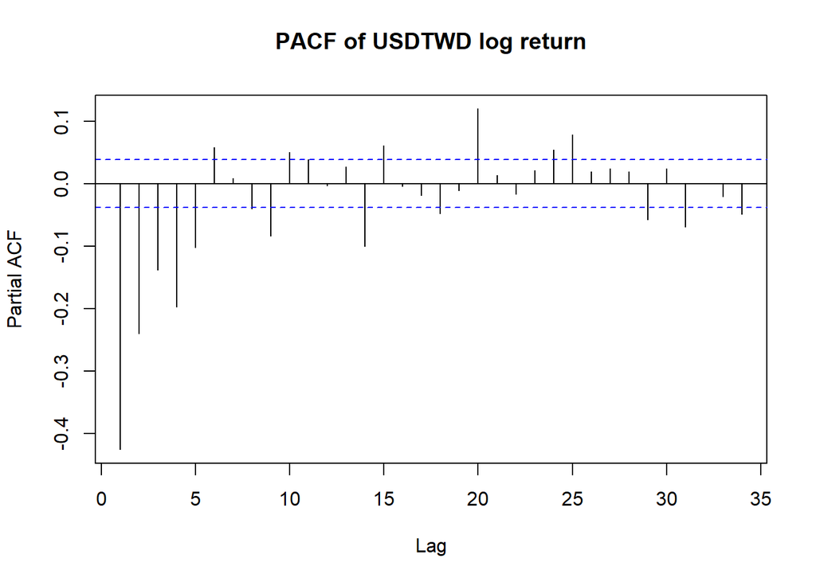

```
##
##  Box-Ljung test
##
## data:  data
## X-squared = 562.25, df = 10, p-value < 2.2e-16
```